# Day 10: Linear Regression — In-Class Activity (Solutions)

How much does a higher price cost in sales?

Instructor

```r
data(Carseats)
```

## Part 1: One Predictor

### Task 1.1: Look first

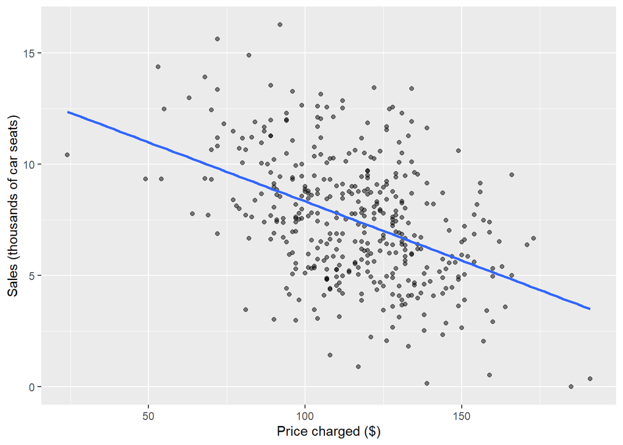

```r
ggplot(Carseats, aes(x = Price, y = Sales)) +
  geom_point(alpha = 0.5) +
  geom_smooth(method = "lm", se = FALSE) +
  labs(x = "Price charged ($)", y = "Sales (thousands of car seats)")
```

The line slopes **down**: stores that charge more sell fewer car seats. The cloud is wide but shows no obvious bend, so a straight line is a reasonable summary.

### Task 1.2: Fit the line

```r
fit_price <- lm(Sales ~ Price, data = Carseats)
coef(fit_price)
```

```
## (Intercept)       Price
## 13.64191518 -0.05307302
```

Each extra dollar of price is associated with 0.053 thousand, or about **53 fewer car seats** sold. A $10 price increase goes with about **530 fewer car seats**.

### Task 1.3: How sure are we?

```r
summary(fit_price)
```

```
##
## Call:
## lm(formula = Sales ~ Price, data = Carseats)
##
## Residuals:
##     Min      1Q  Median      3Q     Max
## -6.5224 -1.8442 -0.1459  1.6503  7.5108
##
## Coefficients:
##              Estimate Std. Error t value Pr(>|t|)
## (Intercept) 13.641915   0.632812  21.558   <2e-16 ***
## Price       -0.053073   0.005354  -9.912   <2e-16 ***
## ---
## Signif. codes:  0 '***' 0.001 '**' 0.01 '*' 0.05 '.' 0.1 ' ' 1
##
## Residual standard error: 2.532 on 398 degrees of freedom
## Multiple R-squared:  0.198,  Adjusted R-squared:  0.196
## F-statistic: 98.25 on 1 and 398 DF,  p-value: < 2.2e-16
```

```r
confint(fit_price)
```

```
##                  2.5 %      97.5 %
## (Intercept) 12.3978438 14.88598655
## Price       -0.0635995 -0.04254653
```

- **Standard error** of the slope: 0.0054.
- **p-value:** about 7.6e-21, essentially 0.
- **95% CI:** -0.064 to -0.043.
- **R-squared:** 0.20.

The true price effect is **not plausibly zero**. Two numbers show it: the p-value is tiny, and the 95% CI is entirely below 0. Price explains about **20%** of the variation in sales across stores.

## Part 2: Holding the Competitor’s Price Fixed

### Task 2.1: Do stores set prices independently?

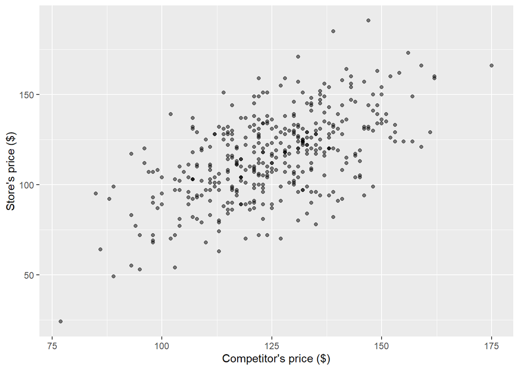

```r
ggplot(Carseats, aes(x = CompPrice, y = Price)) +
  geom_point(alpha = 0.5) +
  labs(x = "Competitor's price ($)", y = "Store's price ($)")
```

```r
cor(Carseats$CompPrice, Carseats$Price)
```

```
## [1] 0.5848478
```

Yes: the correlation is 0.58. Stores charge more where competitors charge more. Plausible reasons: both respond to the same local costs (rent, wages) and local demand, and a store can charge more when the nearby alternative is also expensive.

### Task 2.2: Add the competitor’s price

```r
fit_comp <- lm(Sales ~ Price + CompPrice, data = Carseats)
coef(fit_comp)
```

```
## (Intercept)       Price   CompPrice
##  6.27869205 -0.08745780  0.09077663
```

The `Price` slope grew in magnitude, from -0.053 to **-0.087**. A $10 increase now costs about 870 car seats, not 530.

**Why:** in the simple regression, high-price stores are also the stores with high competitor prices, and a high competitor price **helps** sales (the `CompPrice` slope is +0.091). So part of the damage from a high price was hidden by the boost from expensive competitors, and the simple slope looked too close to zero. Holding `CompPrice` fixed removes that offset. This is **omitted variable bias**, here pushing the estimate toward zero.

**Report to management:** the `fit_comp` estimate. The question is what happens if *we* raise *our* price, and the competitor’s price doesn’t change because we did. That’s exactly the “holding `CompPrice` fixed” comparison.

### Task 2.3: Add more predictors

```r
fit_full <- lm(Sales ~ Price + CompPrice + Advertising + Population, data = Carseats)
summary(fit_full)
```

```
##
## Call:
## lm(formula = Sales ~ Price + CompPrice + Advertising + Population,
##     data = Carseats)
##
## Residuals:
##     Min      1Q  Median      3Q     Max
## -5.8336 -1.4871 -0.1367  1.1841  5.5416
##
## Coefficients:
##               Estimate Std. Error t value Pr(>|t|)
## (Intercept)  5.1791845  0.9028415   5.737 1.92e-08 ***
## Price       -0.0908536  0.0054694 -16.611  < 2e-16 ***
## CompPrice    0.0953619  0.0084719  11.256  < 2e-16 ***
## Advertising  0.1334067  0.0163600   8.154 4.71e-15 ***
## Population   0.0001304  0.0007405   0.176     0.86
## ---
## Signif. codes:  0 '***' 0.001 '**' 0.01 '*' 0.05 '.' 0.1 ' ' 1
##
## Residual standard error: 2.091 on 395 degrees of freedom
## Multiple R-squared:  0.4571, Adjusted R-squared:  0.4516
## F-statistic: 83.15 on 4 and 395 DF,  p-value: < 2.2e-16
```

`Price`, `CompPrice`, and `Advertising` are all significant (p-values far below 0.05). **`Population` is not** (p = 0.86): holding the other three fixed, the data give no evidence that stores in bigger areas sell more car seats.

```r
summary(fit_price)$r.squared
```

```
## [1] 0.1979812
```

```r
summary(fit_comp)$r.squared
```

```
## [1] 0.3578332
```

```r
summary(fit_full)$r.squared
```

```
## [1] 0.4571059
```

R-squared rises at every step. Adding `Population` moved it only from 0.45706 (the same model without `Population`) to 0.45711. R-squared is computed on the **training** data, and least squares can always set a new slope to exactly 0 to match the old fit. So adding a predictor can never make RSS bigger: it can only stay put or shrink by fitting a little noise. That’s Day 9’s point that training MSE never rises as flexibility grows. A higher R-squared alone doesn’t show a predictor is real.

## Part 3: Predict One Store

### Task 3.1: Predict one store

```r
new_store <- data.frame(Price = 110, CompPrice = 125, Advertising = 10, Population = 300)
predict(fit_full, new_store, interval = "confidence")
```

```
##        fit      lwr      upr
## 1 8.478704 8.236507 8.720902
```

```r
predict(fit_full, new_store, interval = "prediction")
```

```
##        fit      lwr      upr
## 1 8.478704 4.359998 12.59741
```

The model predicts about **8,480 car seats**.

- The **confidence interval** (8.24 to 8.72 thousand) is for the *average* sales of all stores like this one. It reflects only uncertainty about the coefficients, which is small with 400 stores.
- The **prediction interval** (4.36 to 12.60 thousand) is for *this one* store, which can land well off the line. It also allows for that typical miss (RSE ≈ 2.1 thousand), the irreducible error, so it is much wider.
- For inventory at one store, use the **prediction interval**.

## Part 4: Check the Fit

### Task 4.1: Residual plot for the car seat model

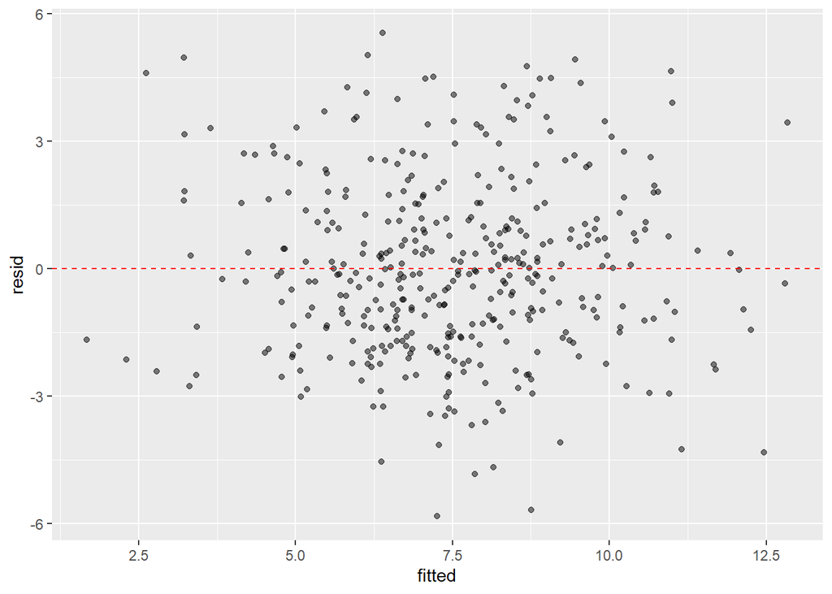

```r
resid_data <- data.frame(fitted = fitted(fit_full), resid = resid(fit_full))

ggplot(resid_data, aes(x = fitted, y = resid)) +
  geom_point(alpha = 0.5) +
  geom_hline(yintercept = 0, linetype = "dashed", color = "red")
```

No U-shape, curve, or fan: the residuals scatter evenly around 0 across the range of fitted values. Nothing in this plot suggests the straight-line model is missing a bend, and the noise looks roughly constant. But this plot can’t show an *omitted variable* that isn’t related to the fitted values. Task 4.2 finds one.

### Task 4.2: Color by shelf location

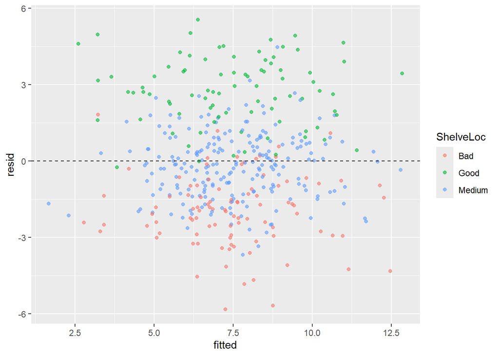

```r
resid_data$ShelveLoc <- Carseats$ShelveLoc

ggplot(resid_data, aes(x = fitted, y = resid, color = ShelveLoc)) +
  geom_point(alpha = 0.6) +
  geom_hline(yintercept = 0, linetype = "dashed")
```

The same plot now splits into layers. Almost all Good-shelf stores sit **above** the zero line (98% have positive residuals), and most Bad-shelf stores sit **below** it (91% negative). Medium-shelf stores are spread around zero.

So `fit_full` systematically **underpredicts** sales for stores with a good shelf spot and **overpredicts** for stores with a bad one. Shelf location affects sales, and the model leaves it out. The plot in Task 4.1 looked fine only because shelf location isn’t related to the fitted values. Adding `ShelveLoc` to the model (Bonus 2) fixes this.

## Bonus

### Bonus 1: Two questions to think about

1. **Right:** price alone leaves most of the store-to-store variation in sales unexplained (R-squared ≈ 0.20). **Wrong:** R-squared measures how much of the *total* variation one predictor explains, not how much price *matters*. The slope is large in business terms (about 87 car seats per dollar, holding competitor price fixed) and its p-value is essentially 0. A variable can matter a lot and still explain a modest share of variation when many other things also drive sales.
2. Possible answers, any with a sensible direction:
   - **Local income:** richer areas may support higher prices *and* buy more, which hides some of the price effect, so adding income would make the price slope more negative.
   - **Store size or foot traffic:** big, busy stores may sell more and also price differently.
   - **Shelf location** (in the data as `ShelveLoc`; see Task 4.2 and Bonus 2).
   - **Brand or product quality**, if some stores stock a pricier, better model.

### Bonus 2: A category as a predictor

```r
fit_shelf <- lm(Sales ~ Price + CompPrice + Advertising + ShelveLoc, data = Carseats)
summary(fit_shelf)
```

```
##
## Call:
## lm(formula = Sales ~ Price + CompPrice + Advertising + ShelveLoc,
##     data = Carseats)
##
## Residuals:
##     Min      1Q  Median      3Q     Max
## -3.7623 -0.8846  0.0415  0.9146  4.4649
##
## Coefficients:
##                  Estimate Std. Error t value Pr(>|t|)
## (Intercept)      3.844428   0.564487    6.81 3.65e-11 ***
## Price           -0.093592   0.003500  -26.74  < 2e-16 ***
## CompPrice        0.093744   0.005398   17.37  < 2e-16 ***
## Advertising      0.120280   0.010121   11.88  < 2e-16 ***
## ShelveLocGood    4.729319   0.199910   23.66  < 2e-16 ***
## ShelveLocMedium  1.772761   0.163926   10.81  < 2e-16 ***
## ---
## Signif. codes:  0 '***' 0.001 '**' 0.01 '*' 0.05 '.' 0.1 ' ' 1
##
## Residual standard error: 1.338 on 394 degrees of freedom
## Multiple R-squared:  0.7782, Adjusted R-squared:  0.7754
## F-statistic: 276.5 on 5 and 394 DF,  p-value: < 2.2e-16
```

`Bad` is missing: it is the **baseline** (R uses the first level alphabetically). Each shelf coefficient compares that shelf to `Bad`. A model can’t include all three, because the three dummies always sum to 1 and would duplicate the intercept.

Holding price, competitor price, and advertising fixed, a Good shelf sells about **4,730 more car seats** than a Bad shelf (and Medium about 1,770 more). R-squared jumps from 0.46 to **0.78**. Shelf location was the big omitted factor, and unlike `Population`, this rise comes with tiny p-values.

### Bonus 3: Is the price effect the same on every shelf?

```r
fit_inter <- lm(Sales ~ Price * ShelveLoc + CompPrice + Advertising, data = Carseats)
summary(fit_inter)
```

```
##
## Call:
## lm(formula = Sales ~ Price * ShelveLoc + CompPrice + Advertising,
##     data = Carseats)
##
## Residuals:
##     Min      1Q  Median      3Q     Max
## -3.7215 -0.8714  0.0141  0.9151  4.3350
##
## Coefficients:
##                        Estimate Std. Error t value Pr(>|t|)
## (Intercept)            3.226226   0.820471   3.932 9.95e-05 ***
## Price                 -0.088889   0.006077 -14.627  < 2e-16 ***
## ShelveLocGood          5.087630   0.973866   5.224 2.85e-07 ***
## ShelveLocMedium        2.693962   0.819960   3.285  0.00111 **
## CompPrice              0.094377   0.005443  17.339  < 2e-16 ***
## Advertising            0.120667   0.010140  11.900  < 2e-16 ***
## Price:ShelveLocGood   -0.003197   0.008206  -0.390  0.69708
## Price:ShelveLocMedium -0.008028   0.007006  -1.146  0.25253
## ---
## Signif. codes:  0 '***' 0.001 '**' 0.01 '*' 0.05 '.' 0.1 ' ' 1
##
## Residual standard error: 1.339 on 392 degrees of freedom
## Multiple R-squared:  0.779,  Adjusted R-squared:  0.7751
## F-statistic: 197.4 on 7 and 392 DF,  p-value: < 2.2e-16
```

Neither interaction is significant (p = 0.70 for Good, 0.25 for Medium). The data give no evidence that a good shelf makes customers less price-sensitive. A good shelf **shifts sales up**, by about the same amount at every price, but the price slope looks the same on every shelf.